# 案例學習五

－－－－－－－－－－－－－－－－－－－－－－－－－－－－－－

> 期中期待
- (給入門起跑者) [Learning path on DS/R](https://www.analyticsvidhya.com/learning-paths-data-science-business-analytics-business-intelligence-big-data/learning-path-r-data-science/)
- (給打算入行者) [Skills checklist](http://1onjea25cyhx3uvxgs4vu325-wpengine.netdna-ssl.com/wp-content/uploads/2014/12/UdacityUltimateSkillChecklistForYourFirstDataAnalystJob.pdf)
- (給雄心壯志者) [Toward Kaggle competition](https://www.analyticsvidhya.com/blog/2015/12/kaggle-solution-cooking-text-mining-competition/)

－－－－－－－－－－－－－－－－－－－－－－－－－－－－－－

```r
library(jiebaR)
library(tidyverse)
library(tidytext)
library(wordcloud2)
```

# Exploratory (Textual) Data Analysis

E(T)DA 兩個核心知識技能：

- Statistics
- Graphics：可以試著用例子去學。參考 [R graph gallery](http://www.r-graph-gallery.com/) 或 [Python graph gallery](https://python-graph-gallery.com/)

文本資料多了什麼？

- 前處理 Pre-processing ([編碼處理](http://cn.qinwenfeng.com/ropencc/)，[中文斷詞](http://qinwenfeng.com/jiebaR/))
- [字串處理 String manipulation](http://www.gastonsanchez.com/Handling_and_Processing_Strings_in_R.pdf), esp. (linguistic) pattern extraction
- 語料庫 corpus 與詞庫 lexicon

# Case study: FB as Data

臉書是重要的社會網路，記錄這個時代不少的 human data。

> 先想像妳的問題與興趣

### Authentication process to access Facebook from R

想撈取 Facebook 上的資料，須先取得 facebook 的**權限認證**。認證方式有兩種，一種是建立 Facebook App 的方式，另一種則是直接產生一個暫時的**存取權杖**（token），不管使用那一種都可以。

`參考：https://blog.gtwang.org/r/facebook-social-media-mining-with-r/`

#### 第一種方式：建立一個 Facebook App，以取得通過 Facebook 的權限認證機制，

- 註冊進入 https://developers.facebook.com/
- 於右上方「我的應用程式」中，點選「新增應用程式」，輸入驗證碼。
- 取一個任意的 App 的名稱後，點選下方建立新的 Facebook 應用程式編號(Create New Facebook App ID)。先把「應用程式編號」和「應用程式密鑰」記下來。
- OAuth Settings：
  - 到左下按「新增產品」
  - 選「Facebook 登入」-「設定」- 「網站」- 填入 http://localhost:1410/ - 儲存

```r
fb_oauth <- fbOAuth(
  app_id = "125584644779971",                          # 填入應用程式編號
  app_secret = "0a0e8a552fd762b4f6eda05bdccd1ac6")     # 填入應用程式密鑰
```

```
Waiting for authentication in browser...
Press Esc/Ctrl + C to abort
Authentication complete.
Authentication successful.
```

#### 第二種方式：取得 Facebook 存取權杖（Token）

不需建立 facebook app，只要從網頁上產生存取權杖代碼即可使用，不過時效只有兩小時，過期後就要重新產生。

- 到 `https://developers.facebook.com/tools/explorer` -「取得權杖」- 「取得用戶存取權杖」
- 選擇要開放的權限。
- 複製產生的存取權杖代碼，放在 R 的 token 變數中。

> 好心的助教： http://lope.linguistics.ntu.edu.tw/rlads/

```r
token <- 'EAACEdEose0cBAK65fKDTxlZBnE6dMcZBeVemfzWSKJQ76uAwk66ulhF6c38…'
```

### 開始擷取資料分析

參考 `Rfacebook` 的[套件說明](https://cran.r-project.org/web/packages/Rfacebook/Rfacebook.pdf)。 這個較新的[使用簡易說明](http://www.listendata.com/2017/03/facebook-data-mining-using-r.html)也可參考（因應 FB 的 api policy）

- The `getUsers` function returns public information about one or more Facebook user.

```r
#me <- getUsers("me", token, private_info = TRUE)
me <- getUsers("me",token=fb_oauth)
me$name
```

```
[1] "Eddy Yang"
```

- `searchPages()`, `getPost()`(needs some tweak)

```r
pages <- searchPages('data science with R', token)
```

```
11 pages
```

```r
#pages <- searchPages('data science with R', fb_oauth)
```

- 所有我按讚的頁面

```r
likes = getLikes(user="me", token = token)
sample(likes$names, 10)
```

```
 [1] "亞洲統神-張嘉航"            "日出紙楓資訊站"
 [3] "Pau Gasol"                  "戰鬥吧！好奇小白兔"
 [5] "民主進步黨"                 "Waffles the Cat"
 [7] "吾命騎士"                   "2017台大生科營《基因風暴》"
 [9] "Nala_cat"                   "FamePop飛夢娱乐文化"
```

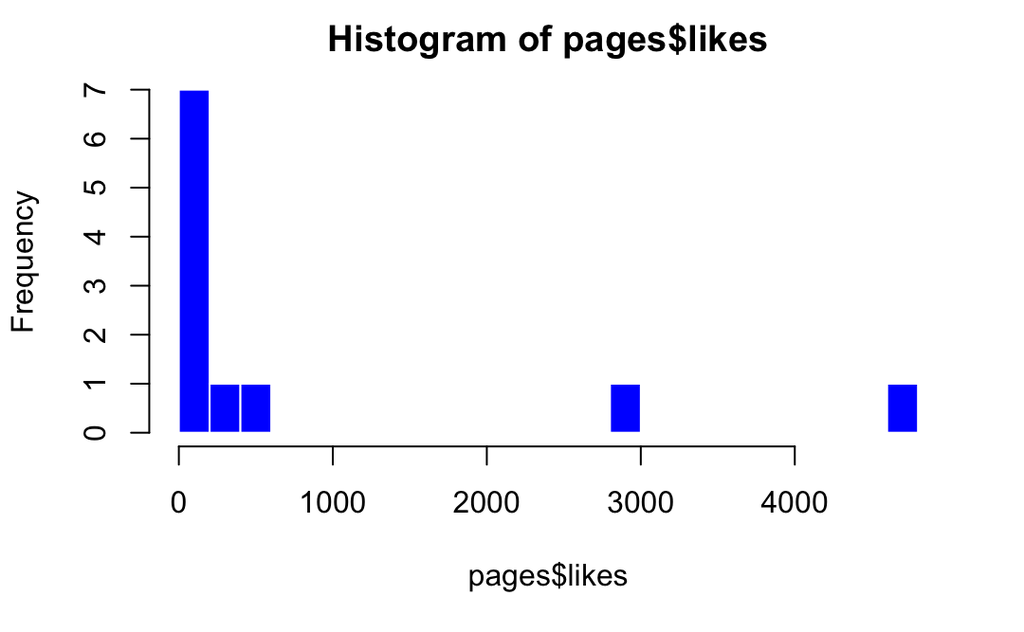

```r
hist(pages$likes, col="blue", border = "white", breaks = 25)
```

- 含有特定字詞的頁面

```r
pages <- searchPages(string="LOL", token = token, n=50)
```

```
50 pages
```

```r
# It returns 16 variables. check with str(pages)
head(pages$name)
```

```
[1] "League of Legends" "《英雄聯盟-LoL》"  "~LoL~"
[4] "LOL Esports"       "LOL"               "Lolita"
```

- 抽取特定頁面的所有貼文

```r
BBCpage <- getPage(page="bbcnews", token = token, n=50)
```

```
25 posts 50 posts
```

- 特定時間的所有貼文

```r
BBCpage.2 <- getPage("bbcnews", token = token, n=50, since='2017/10/01', until='2017/10/20')
```

```
25 posts 50 posts
```

- 哪那一則貼文得到最多的讚?

```r
summary <- BBCpage.2[which.max(BBCpage.2$likes_count),]
summary$message
```

```
[1] "Bodyform decided to ditch the blue liquid, saying it wants to confront the taboos about periods."
```

- 哪一則得到最多的評論?

```r
summary1 = BBCpage.2[which.max(BBCpage.2$comments_count),]
```

- 哪一則貼文最多分享?

```r
summary2 = BBCpage.2[which.max(BBCpage.2$shares_count),]
```

- 得到最多讚的貼文的所有按讚者

```r
post <- getPost(summary$id[1], token = token, comments = FALSE, n.likes=2000)
```

- 看看究竟是誰（注意個資）

```r
likes <- post$likes
head(likes)
```

|  | from_name | from_id |
| --- | --- | --- |
| 1 | Robert Joseph | 140102683407666 |
| 2 | မုန္းမုန္း ခက္ | 182764305663059 |
| 3 | نظرمحمد افغان | 134138820674126 |
| 4 | Sarah Kate | 10152978404761213 |
| 5 | Alison Louise | 10203764013554891 |
| 6 | မာန မင္းသား | 105786270109167 |

- 特定貼文的評論

To know what users think about a post, it is important to analyze their comments.

```r
post <- getPost(BBCpage.2$id[1], token=token, n.comments=1000, likes=FALSE)
comments <- post$comments
```

- 哪個評論得到最多的讚？

```r
comments[which.max(comments$likes_count),]
```

|  | from_id | from_name | message | created_time | likes_count | comments_count | id |
| --- | --- | --- | --- | --- | --- | --- | --- |
| 1 | 10152538450348277 | Imran Khan | The Chicago institute later put out an apology, they meant to say Trump was a fake and not the painting. | 2017-10-19T23:41:09+0000 | 1811 | 82 | 10155229891317217_10155229893867217 |

- 最近貼文的心情（需要 tweak）

Facebook has more than a like button. Last year, it launched emoji (emoticons). If a post got 1k likes, it does not mean everyone really loves the comment. The reaction can be happy, sad or angry.

```r
post <- getReactions(post=BBCpage.2$id[1], token= token)
```

```
Error in callAPI(url = url, token = token, api = api) :
  (#12) Reactions read API requires version v2.6 or higher
```

# 期中考前說明

- 3 小時個人考試
- 6 天團體加分題：微計畫